# Homework 5

18 November, 2023

**Due November 15 prior to 1:30 PM. Assignments are to be submitted via Canvas.**

**You may discuss the homework problems and computing issues with other students in the class and submit questions to the Canvas discussion board. However, you must write up your homework solution on your own. In particular, do not share your R files with other students. Please list the students you worked with below.**

Students worked with: XXXXX

Lectures: Module 5

Objectives:

1. Fit and interpret an additive model.
2. Examine different basis functions and smoothing parameter selection in mgcv::gam.
3. Model the interaction between a factor and continuous variable in GAMs.

# 1 Problem 1.

In general, people experience a decline in cognitive function with age. Dementia is defined as serious cognitive decline that impacts everyday activities. People with mild cognitive impairment (MCI) are generally able to perform daily activities, but have greater decline in cognitive function than in typical aging. Many people with MCI eventually develop Alzheimer’s Disease or other types of dementia.

We will use a dataset containing an imaging biomarker, a genetic biomarker, and demographic information, defined below. The dataset (MCI.RData) contains data related to the Alzheimer’s Disease Neuroimaging Initiative (http://adni.loni.usc.edu/tadpole-challenge-dataset-available/). Parts of the data have been simulated in order to allow data sharing for educational purposes. Qualitatively, the results you discover in this educational dataset are likely to be the same as in the unaltered dataset.

Variable Codebook:

1. ID Participant identifier.
2. VISIT Visit time in months since baseline.
3. DX
- 0 = normal aging
- 1 = MCI
4. AGE_VISIT Participant’s age at the time of the visit.
5. PTGENDER Participant gender.
- Female
- Male
6. PTEDUCAT Total years of education.
7. APOE4 Numeric variable equal to 0, 1, or 2 indicating the individual has 0, 1, or 2 copies of the E4 allele of apolipoprotein. This genetic variant is linked to the formation of amyloid beta deposits in the brain, which is one of the characteristics of Alzheimer’s Disease.
8. HIPPOCAMPUS_VOL Volume of the right plus left hippocampus in mm^3. The hippocampus is a subcortical gray matter structure in the brain that is associated with memory.

We will subset to cross-sectional data. We do this for educational purposes, as we want to fit variants of the model a few times to understand the effects of different spline specifications. It takes a long time to fit the longitudinal gam. So for this homework, it is easier to work with the cross-sectional data. Please note that in your own research projects and future jobs, you will of course want to use all of your data.

Create the cross-sectional dataset and convert hippocampus volume to cm^3:

```r
load("MCI.RData")
mcidata$HIPPOCAMPUS_VOL=mcidata$HIPPOCAMPUS_VOL/1000
mcidata$APOE4 = factor(mcidata$APOE4)
mcidata = mcidata[complete.cases(mcidata),]
mcidata_cx = mcidata[!duplicated(mcidata$ID),]
```

## 1.1

Using mathematical notation, with $g_j(x_{ij})$ for smooth terms, write out a statistical model with normal errors for the cross-sectional data with $y_i$ denoting hippocampus volume in cm^3 and the covariates `DX`, `PTGENDER`, `APOE4` (treating APOE4 as a factor with reference level 0), a smooth for `AGE_VISIT`, and a smooth for `PTEDUCAT`. Include distributional assumptions. (You do not need to write the basis functions used for the smooth terms $g_j(x_{ij})$, nor the penalized objective function.)

## 1.2

Fit this model using `mgcv::gam`. Use all defaults. Print the output of summary.

```r
library(mgcv)
model1.2 <- gam(HIPPOCAMPUS_VOL ~ DX + PTGENDER + APOE4 + s(AGE_VISIT) + s(PTEDUCAT), data = mcidata_cx)

summary(model1.2)
```

```
##
## Family: gaussian
## Link function: identity
##
## Formula:
## HIPPOCAMPUS_VOL ~ DX + PTGENDER + APOE4 + s(AGE_VISIT) + s(PTEDUCAT)
##
## Parametric coefficients:
##              Estimate Std. Error t value Pr(>|t|)
## (Intercept)   6.90924    0.06425 107.530  < 2e-16 ***
## DX           -0.86349    0.07042 -12.263  < 2e-16 ***
## PTGENDERMale  0.42804    0.06699   6.390 2.73e-10 ***
## APOE41       -0.23431    0.07088  -3.306 0.000987 ***
## APOE42       -0.69546    0.12882  -5.399 8.72e-08 ***
## ---
## Signif. codes:  0 '***' 0.001 '**' 0.01 '*' 0.05 '.' 0.1 ' ' 1
##
## Approximate significance of smooth terms:
##                edf Ref.df      F p-value
## s(AGE_VISIT) 2.046  2.597 98.630  <2e-16 ***
## s(PTEDUCAT)  1.939  2.458  0.784   0.557
## ---
## Signif. codes:  0 '***' 0.001 '**' 0.01 '*' 0.05 '.' 0.1 ' ' 1
##
## R-sq.(adj) =  0.342   Deviance explained = 34.8%
## GCV = 0.91312  Scale est. = 0.90356   n = 858
```

## 1.3

Create diagnostic plots using `gam.check()`. Briefly comment on each of the four plots. Are there any issues?

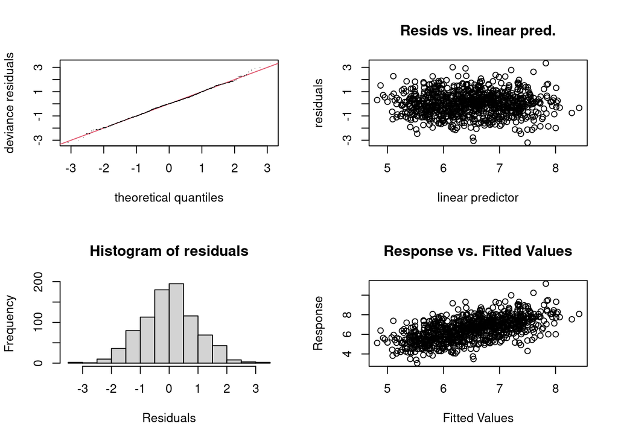

```
##
## Method: GCV   Optimizer: magic
## Smoothing parameter selection converged after 6 iterations.
## The RMS GCV score gradient at convergence was 3.819307e-06 .
## The Hessian was positive definite.
## Model rank =  23 / 23
##
## Basis dimension (k) checking results. Low p-value (k-index<1) may
## indicate that k is too low, especially if edf is close to k'.
##
##                k'  edf k-index p-value
## s(AGE_VISIT) 9.00 2.05    1.01   0.605
## s(PTEDUCAT)  9.00 1.94    0.93   0.025 *
## ---
## Signif. codes:  0 '***' 0.001 '**' 0.01 '*' 0.05 '.' 0.1 ' ' 1
```

```r
gam.check(model1.2)
```

The first plot is the QQ plot of deviance residuals. The data does not deviate too much from the straight line, suggesting that the normality assumption is not violated.

The second plot is the residuals vs. linear predictor plot. The residuals appear to be randomly scattered around zero, indicating that the model may be adequate for capturing the underlying relationship of the data and the homoscedasticity assumption is not violated.

The third plot is the histogram of residuals. The distribution of residuals looks very similar to the standard normal distribution, indicating that our normality assumption is not violated.

## 1.4

State the null hypothesis for each p-value in the spline basis dimension diagnostics in `gam.check()`. Then state whether it is accepted or rejected at $\alpha=0.05$.

For `AGE_VISIT`, $H_0$: The basis dimension k = 10 for `AGE_VISIT` is adequate. The p-value is greater than our $\alpha = 0.05$. We fail to reject the null hypothesis and conclude that the basis dimension k = 10 is adequate for `AGE_VISIT`.

For `PTEDUCAT`, $H_0$: The basis dimension k = 10 for `PTEDUCAT` is adequate. The p-value is smaller than our $\alpha = 0.05$. We reject the null hypothesis and conclude that the basis dimension k = 10 might be insufficient for `PTEDUCAT`.

## 1.5

Next, inspect the effective degrees of freedom versus k’ in `gam.check()`. Does this approach suggest that k is adequate?

The effective degrees of freedom are 2.05 and 1.94 for `AGE_VISIT` and `PTEDUCAT`, respectively, which are much smaller than k’ = 9. These suggest that k = 10 is adequate.

## 1.6

Try to refit the model with k=20 for `PTEDUCAT`. Why did you receive an error?

```r
model1.6 <- gam(HIPPOCAMPUS_VOL ~ DX + PTGENDER + APOE4 + s(AGE_VISIT) + s(PTEDUCAT, k = 20), data = mcidata_cx)
```

We recieve an error “Error in smooth.construct.tp.smooth.spec(object, dk$data, dk$knots) : A term has fewer unique covariate combinations than specified maximum degrees of freedom”.

## 1.7

Re-fit the model with k set to the maximum possible for `PTEDUCAT`. Print the results of `gam.check()`. Did the edf change? Using the criteria of the change in edf, is k=10 sufficient for modeling the impact of `PTEDUCAT`?

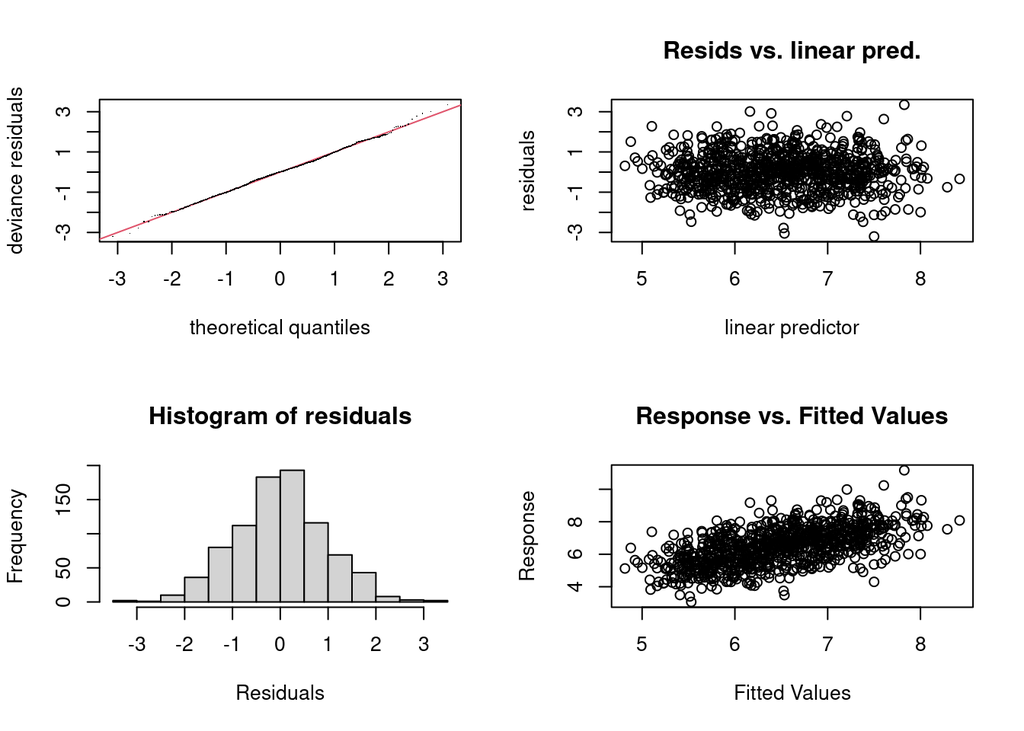

```
##
## Method: GCV   Optimizer: magic
## Smoothing parameter selection converged after 4 iterations.
## The RMS GCV score gradient at convergence was 6.830394e-08 .
## The Hessian was positive definite.
## Model rank =  28 / 28
##
## Basis dimension (k) checking results. Low p-value (k-index<1) may
## indicate that k is too low, especially if edf is close to k'.
##
##                 k'   edf k-index p-value
## s(AGE_VISIT)  9.00  2.05    1.01   0.575
## s(PTEDUCAT)  14.00  1.91    0.93   0.005 **
## ---
## Signif. codes:  0 '***' 0.001 '**' 0.01 '*' 0.05 '.' 0.1 ' ' 1
```

```r
model1.7 <- gam(HIPPOCAMPUS_VOL ~ DX + PTGENDER + APOE4 + s(AGE_VISIT) + s(PTEDUCAT, k = 15), data = mcidata_cx)

gam.check(model1.7)
```

The edf for `s(AGE_VISIT)` = 2.05 is the same for k = 10 and k = 15. The edf for `s(PTEDUCAT)` slightly changes from 1.94 to 1.91. These minimal changes indicate that k = 10 is sufficient for both `AGE_VISIT` and `PTEDUCAT`.

## 1.8

Let’s go back to the model with defaults k=10 from 1.2. Create a plot of the smooth for `AGE_VISIT` using `plot()`.

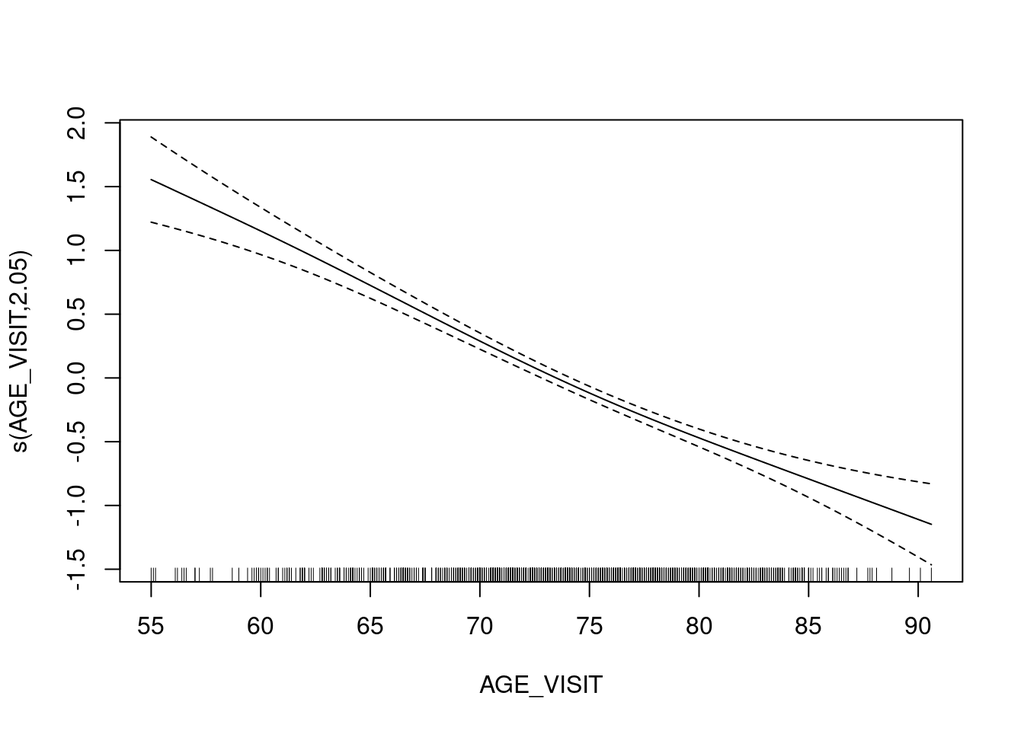

```r
plot(model1.2, select = 1)
```

## 1.9

Now create a plot of the smooth for `AGE_VISIT` using `itsadug::plot_smooth()`.

```r
library(itsadug)
```

```
## Summary:
##  * DX : numeric predictor; set to the value(s): 1.
##  * PTGENDER : factor; set to the value(s): Male.
##  * APOE4 : factor; set to the value(s): 0.
##  * AGE_VISIT : numeric predictor; with 30 values ranging from 55.000000 to 90.600000.
##  * PTEDUCAT : numeric predictor; set to the value(s): 16.
##  * NOTE : No random effects in the model to cancel.
##
```

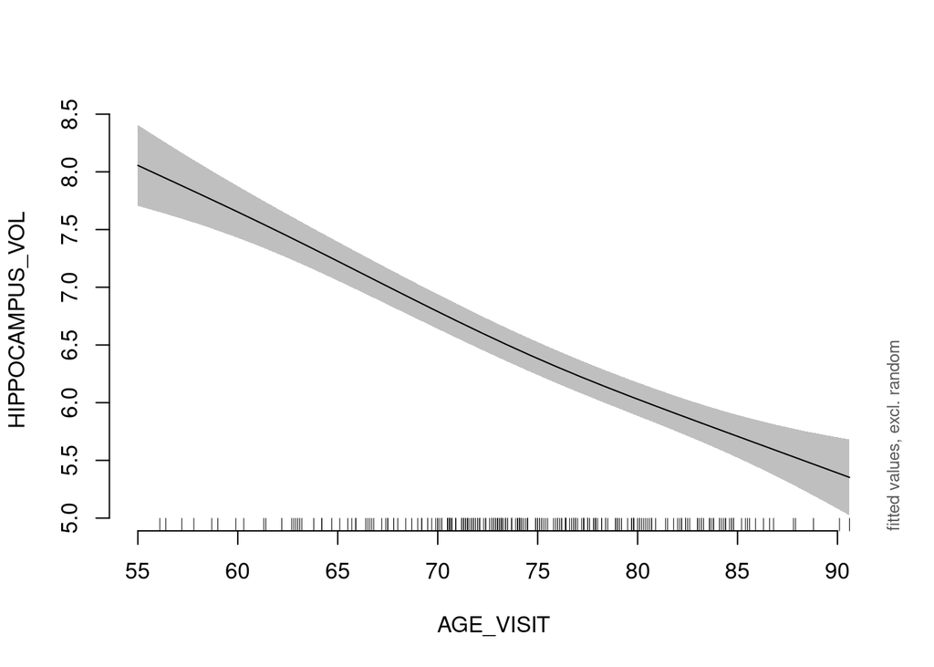

```r
plot_smooth(model1.2, view = "AGE_VISIT")
```

## 1.10

What does the black curve in 1.9 represent? Use your notation from 1.1. What does the black curve in 1.8 represent?

1.9: $\hat{\beta}_0 + \hat{\beta}_1 + \hat{\beta}_2 + \hat{g}_1({AGE\_VISIT}_i) + \hat{g}_2(16)$.

1.8: $\hat{g}_1({AGE\_VISIT})$.

## 1.11

Write out the coefficient estimates and the parametric term values that contribute to the standard errors used in the confidence intervals in 1.9. For example, if only the intercept, $x_{i1}=1$ and the smooth for `AGE_VISIT` contribute, the formula would be $Var [ \hat{\beta}_0+\hat{\beta}_1 *1 + \hat{g}(AGE\_VISIT)]$. Do the same for the terms that contribute to the standard errors used in 1.8.

1.9: $Var[\hat{\beta}_0 + \hat{\beta}_1 + \hat{\beta}_2 + \hat{g}_1({AGE\_VISIT}) + \hat{g}_2(16)]$.

1.8: $Var[\hat{g}_1({AGE\_VISIT})]$.

## 1.12

Re-fit the model with cubic regression splines for both smooth terms. Use k=10. Print the output of `summary()`.

```r
model1.12 <- gam(HIPPOCAMPUS_VOL ~ s(AGE_VISIT, bs="cr", k = 10) + s(PTEDUCAT, bs="cr", k = 10) + DX + PTGENDER + APOE4, data = mcidata_cx)
summary(model1.12)
```

```
##
## Family: gaussian
## Link function: identity
##
## Formula:
## HIPPOCAMPUS_VOL ~ s(AGE_VISIT, bs = "cr", k = 10) + s(PTEDUCAT,
##     bs = "cr", k = 10) + DX + PTGENDER + APOE4
##
## Parametric coefficients:
##              Estimate Std. Error t value Pr(>|t|)
## (Intercept)   6.90925    0.06425 107.530  < 2e-16 ***
## DX           -0.86358    0.07042 -12.263  < 2e-16 ***
## PTGENDERMale  0.42807    0.06699   6.391 2.72e-10 ***
## APOE41       -0.23427    0.07088  -3.305 0.000989 ***
## APOE42       -0.69544    0.12882  -5.398 8.73e-08 ***
## ---
## Signif. codes:  0 '***' 0.001 '**' 0.01 '*' 0.05 '.' 0.1 ' ' 1
##
## Approximate significance of smooth terms:
##                edf Ref.df     F p-value
## s(AGE_VISIT) 2.055  2.606 98.03  <2e-16 ***
## s(PTEDUCAT)  1.954  2.474  0.52   0.555
## ---
## Signif. codes:  0 '***' 0.001 '**' 0.01 '*' 0.05 '.' 0.1 ' ' 1
##
## R-sq.(adj) =  0.342   Deviance explained = 34.8%
## GCV = 0.91311  Scale est. = 0.90352   n = 858
```

## 1.13

Create a plot of the smooth for `AGE_VISIT` from the previous question. For this and all questions hereafter regarding plotting smooths, use `itsadug::plot_smooth()`. How does it compare to the smooth from the thin plate regression spline? Hint: you can use `add=TRUE` in `plot_smooth()` to overlay functions.

```r
smooth_plot_thin_plate <- plot_smooth(model1.2, view = "AGE_VISIT", col = "blue")
```

```
## Summary:
##  * DX : numeric predictor; set to the value(s): 1.
##  * PTGENDER : factor; set to the value(s): Male.
##  * APOE4 : factor; set to the value(s): 0.
##  * AGE_VISIT : numeric predictor; with 30 values ranging from 55.000000 to 90.600000.
##  * PTEDUCAT : numeric predictor; set to the value(s): 16.
##  * NOTE : No random effects in the model to cancel.
##
```

```r
plot_smooth(model1.12, view = "AGE_VISIT", add = TRUE, col = "red")
```

```
## Summary:
##  * DX : numeric predictor; set to the value(s): 1.
##  * PTGENDER : factor; set to the value(s): Male.
##  * APOE4 : factor; set to the value(s): 0.
##  * AGE_VISIT : numeric predictor; with 30 values ranging from 55.000000 to 90.600000.
##  * PTEDUCAT : numeric predictor; set to the value(s): 16.
##  * NOTE : No random effects in the model to cancel.
##
```

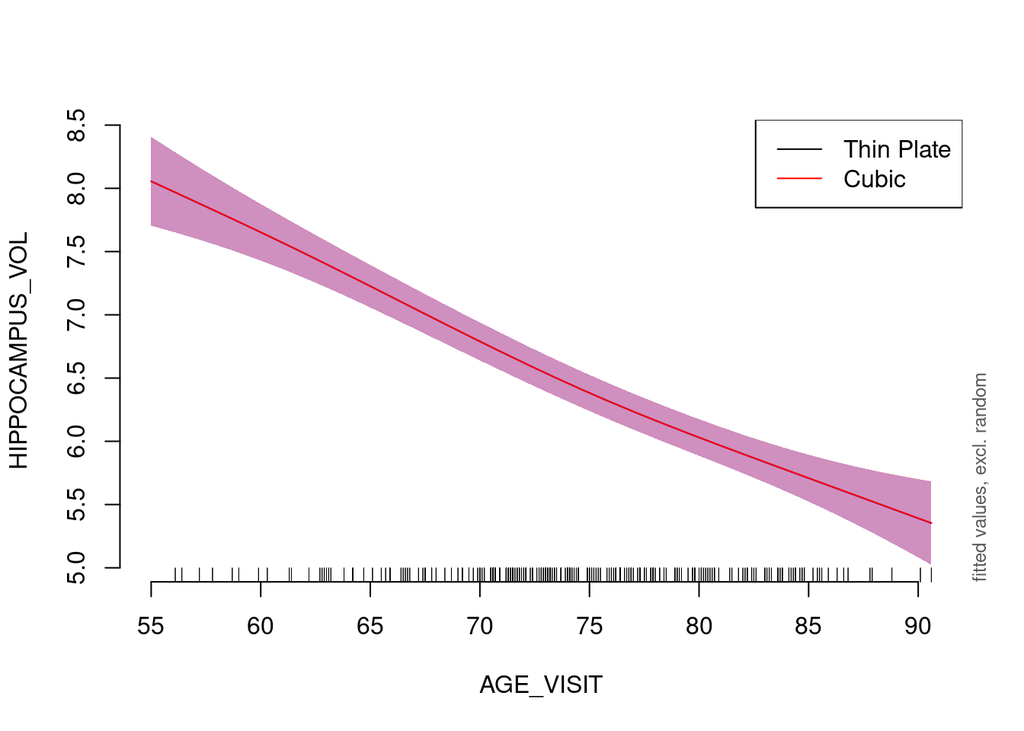

```r
legend("topright", legend = c("Thin Plate", "Cubic"), col = c("black", "red"), lty = 1)
```

The smooth for `AGE_VISIT` from thin plate regression spline and cubic regression splines are very similar.

## 1.14

Now fit the model with thin plate regression splines (i.e., going back to the default splines) using the mixed model random slope approach with REML for tuning parameter selection instead of GCV.

```r
model1.14 <- gam(HIPPOCAMPUS_VOL ~ s(AGE_VISIT) + s(PTEDUCAT) + DX + PTGENDER + APOE4,
                 data = mcidata_cx, method = "REML")
summary(model1.14)
```

```
##
## Family: gaussian
## Link function: identity
##
## Formula:
## HIPPOCAMPUS_VOL ~ s(AGE_VISIT) + s(PTEDUCAT) + DX + PTGENDER +
##     APOE4
##
## Parametric coefficients:
##              Estimate Std. Error t value Pr(>|t|)
## (Intercept)   6.90933    0.06425 107.538  < 2e-16 ***
## DX           -0.86315    0.07040 -12.261  < 2e-16 ***
## PTGENDERMale  0.42771    0.06699   6.385 2.82e-10 ***
## APOE41       -0.23459    0.07088  -3.310 0.000974 ***
## APOE42       -0.69569    0.12882  -5.400 8.63e-08 ***
## ---
## Signif. codes:  0 '***' 0.001 '**' 0.01 '*' 0.05 '.' 0.1 ' ' 1
##
## Approximate significance of smooth terms:
##                edf Ref.df       F p-value
## s(AGE_VISIT) 2.005  2.544 100.718  <2e-16 ***
## s(PTEDUCAT)  1.752  2.213   0.712   0.556
## ---
## Signif. codes:  0 '***' 0.001 '**' 0.01 '*' 0.05 '.' 0.1 ' ' 1
##
## R-sq.(adj) =  0.342   Deviance explained = 34.7%
## -REML = 1185.8  Scale est. = 0.90382   n = 858
```

## 1.15

Create a plot of the smooth term for `AGE_VISIT` for the model in 1.14. How does it compare to the plot from GCV in 1.9? How do the effective degrees of freedom compare?

```
## Summary:
##  * DX : numeric predictor; set to the value(s): 1.
##  * PTGENDER : factor; set to the value(s): Male.
##  * APOE4 : factor; set to the value(s): 0.
##  * AGE_VISIT : numeric predictor; with 30 values ranging from 55.000000 to 90.600000.
##  * PTEDUCAT : numeric predictor; set to the value(s): 16.
##  * NOTE : No random effects in the model to cancel.
##
```

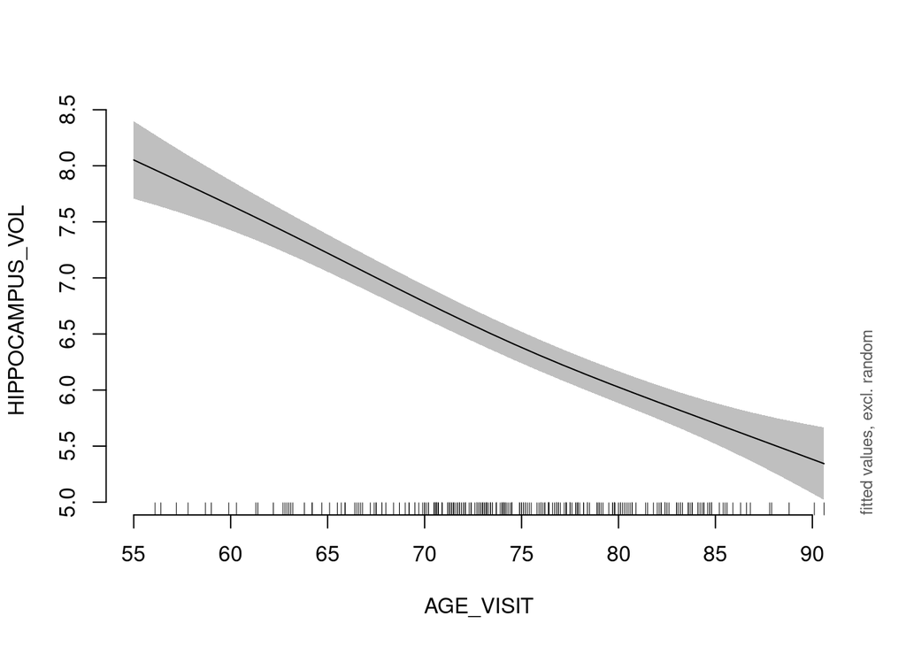

```r
plot_smooth(model1.14, view = "AGE_VISIT")
```

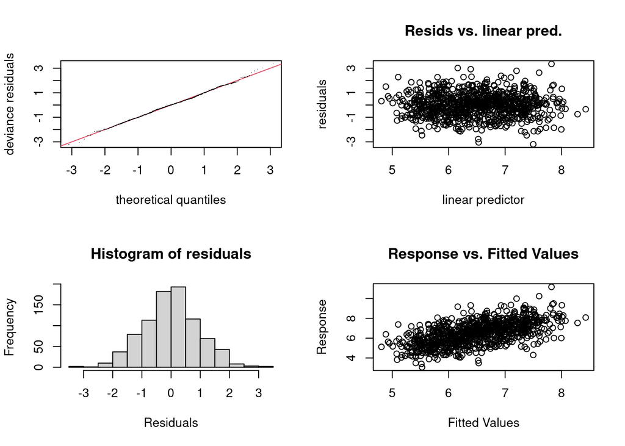

```
##
## Method: REML   Optimizer: outer newton
## full convergence after 5 iterations.
## Gradient range [-0.0001993398,0.0001949697]
## (score 1185.752 & scale 0.903817).
## Hessian positive definite, eigenvalue range [0.1181107,425.5007].
## Model rank =  23 / 23
##
## Basis dimension (k) checking results. Low p-value (k-index<1) may
## indicate that k is too low, especially if edf is close to k'.
##
##                k'  edf k-index p-value
## s(AGE_VISIT) 9.00 2.00    1.01    0.61
## s(PTEDUCAT)  9.00 1.75    0.93    0.01 **
## ---
## Signif. codes:  0 '***' 0.001 '**' 0.01 '*' 0.05 '.' 0.1 ' ' 1
```

```r
gam.check(model1.14)
```

The plot from REML and from GCV are very similar. The EDFs are smaller from REML than from GCV.

## 1.16

Keep using the model from 1.14. Create a plot with simultaneous confidence intervals for the smoother for `AGE_VISIT`. Do this using the package `itsadug()`, `plot_smooth`, and `sim.ci=TRUE`. A nice blog post on simultaneous confidence intervals is https://fromthebottomoftheheap.net/2016/12/15/simultaneous-interval-revisited/. How does the confidence interval compare to the plot that has pointwise confidence bands?

```r
plot_smooth(model1.14, view = "AGE_VISIT", sim.ci = TRUE, col = "red")
```

```
## Summary:
##  * DX : numeric predictor; set to the value(s): 1.
##  * PTGENDER : factor; set to the value(s): Male.
##  * APOE4 : factor; set to the value(s): 0.
##  * AGE_VISIT : numeric predictor; with 200 values ranging from 55.000000 to 90.600000.
##  * PTEDUCAT : numeric predictor; set to the value(s): 16.
##  * NOTE : No random effects in the model to cancel.
##
##  * Simultaneous 95%-CI used :
##      Critical value: 2.684
##      Proportion posterior simulations in pointwise CI: 0.57 (10000 samples)
##      Proportion posterior simulations in simultaneous CI: 0.95 (10000 samples)
##
```

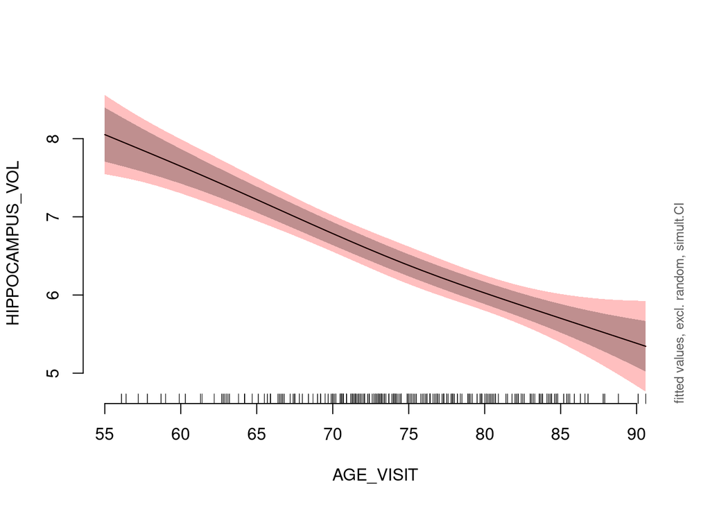

```
## Summary:
##  * DX : numeric predictor; set to the value(s): 1.
##  * PTGENDER : factor; set to the value(s): Male.
##  * APOE4 : factor; set to the value(s): 0.
##  * AGE_VISIT : numeric predictor; with 30 values ranging from 55.000000 to 90.600000.
##  * PTEDUCAT : numeric predictor; set to the value(s): 16.
##  * NOTE : No random effects in the model to cancel.
##
```

```r
plot_smooth(model1.14, view="AGE_VISIT", add = TRUE)
```

The simultaneous confidence intervals are wider than the pointwise confidence bands.

## 1.17

What is the effect of an increase in patient age (`AGE_VISIT`) from 59 to 60 years? For simplicity, do not include CI here.

```r
newd <- mcidata_cx[1, ] # grab any row
newd$AGE_VISIT <- 59 # age = 59
y1 <- predict(model1.14, newd)
newd$AGE_VISIT <- 60 # age = 60
y2 <- predict(model1.14, newd)
y2 - y1
```

```
##          13
## -0.08210043
```

The effect of an increase in patient age (`AGE_VISIT`) from 59 to 60 year is -0.0821004.

## 1.18

What is the effect of an increase in patient age (`AGE_VISIT`) from 80 to 81 years? For simplicity, do not include CI.

```r
newd <- mcidata_cx[1, ] # grab any row
newd$AGE_VISIT <- 80 # subtract some small number
y1 <- predict(model1.14, newd)
newd$AGE_VISIT <- 81 # add some small number
y2 <- predict(model1.14, newd)
y2 - y1
```

```
##         13
## -0.0659635
```

The effect of an increase in patient age (`AGE_VISIT`) from 80 to 81 years is -0.0659635.

## 1.19

Does patient age, as measured with `AGE_VISIT`, impact hippocampal volume? State the approximate p-value and describe the pattern.

Yes. The approximate p-value is $< 2 \times 10^{-16}$. Hippocampal volume decreases almost linearly as `AGE_VISIT` increases.

## 1.20

We will now examine whether there is an interaction between `APOE4` (as a factor) and `AGE_VISIT`. Fit a model with a smoother for this interaction along with all previous terms (including smoother for `PTEDUCAT`). In practice, you could choose GCV or REML; to facilitate grading, use REML. Print the output of summary.

```r
model1.20 <- gam(HIPPOCAMPUS_VOL ~ s(PTEDUCAT) + s(AGE_VISIT, by = APOE4) + DX + PTGENDER + APOE4,  data = mcidata_cx, method = "REML")
summary(model1.20)
```

```
##
## Family: gaussian
## Link function: identity
##
## Formula:
## HIPPOCAMPUS_VOL ~ s(PTEDUCAT) + s(AGE_VISIT, by = APOE4) + DX +
##     PTGENDER + APOE4
##
## Parametric coefficients:
##              Estimate Std. Error t value Pr(>|t|)
## (Intercept)   6.90629    0.06407 107.794  < 2e-16 ***
## DX           -0.85237    0.07039 -12.109  < 2e-16 ***
## PTGENDERMale  0.42738    0.06692   6.387 2.80e-10 ***
## APOE41       -0.23919    0.07042  -3.397 0.000714 ***
## APOE42       -0.59481    0.13810  -4.307 1.85e-05 ***
## ---
## Signif. codes:  0 '***' 0.001 '**' 0.01 '*' 0.05 '.' 0.1 ' ' 1
##
## Approximate significance of smooth terms:
##                       edf Ref.df      F  p-value
## s(PTEDUCAT)         1.774  2.243  0.746 0.539747
## s(AGE_VISIT):APOE40 3.033  3.830 41.693  < 2e-16 ***
## s(AGE_VISIT):APOE41 1.477  1.822 54.538  < 2e-16 ***
## s(AGE_VISIT):APOE42 3.368  4.215  5.407 0.000229 ***
## ---
## Signif. codes:  0 '***' 0.001 '**' 0.01 '*' 0.05 '.' 0.1 ' ' 1
##
## R-sq.(adj) =  0.351   Deviance explained = 36.1%
## -REML = 1185.4  Scale est. = 0.89114   n = 858
```

## 1.21

Does the default $k=10$ appear to be adequate for all smooth terms?

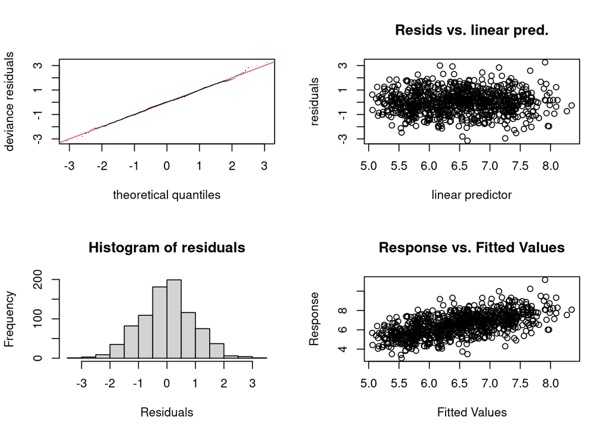

```
##
## Method: REML   Optimizer: outer newton
## full convergence after 5 iterations.
## Gradient range [-9.825084e-05,3.109543e-07]
## (score 1185.441 & scale 0.8911414).
## Hessian positive definite, eigenvalue range [0.08861142,424.5063].
## Model rank =  41 / 41
##
## Basis dimension (k) checking results. Low p-value (k-index<1) may
## indicate that k is too low, especially if edf is close to k'.
##
##                       k'  edf k-index p-value
## s(PTEDUCAT)         9.00 1.77    0.94   0.045 *
## s(AGE_VISIT):APOE40 9.00 3.03    1.02   0.650
## s(AGE_VISIT):APOE41 9.00 1.48    1.02   0.675
## s(AGE_VISIT):APOE42 9.00 3.37    1.02   0.665
## ---
## Signif. codes:  0 '***' 0.001 '**' 0.01 '*' 0.05 '.' 0.1 ' ' 1
```

```r
gam.check(model1.20)
```

As all of the edf values are significantly smaller than k’, suggesting that $k=10$ is adequate.

## 1.22

Create plots to visually assess whether there is an interaction between `APOE4` and `AGE_VISIT`. Use simultaneous confidence intervals and overlay the plots. One way to do this is by adapting the code `cond = list('APOE4'='yourlevel'),add=TRUE,` etc.

```r
plot_smooth(model1.20,view='AGE_VISIT', sim.ci = TRUE, cond = list(APOE4 = 0), rm.ranef=TRUE)
```

```
## Summary:
##  * DX : numeric predictor; set to the value(s): 1.
##  * PTGENDER : factor; set to the value(s): Male.
##  * APOE4 : numeric predictor; set to the value(s): 0.
##  * PTEDUCAT : numeric predictor; set to the value(s): 16.
##  * AGE_VISIT : numeric predictor; with 200 values ranging from 55.000000 to 90.600000.
##  * NOTE : No random effects in the model to cancel.
##
##  * Simultaneous 95%-CI used :
##      Critical value: 2.827
##      Proportion posterior simulations in pointwise CI: 0.41 (10000 samples)
##      Proportion posterior simulations in simultaneous CI: 0.95 (10000 samples)
##
```

```r
plot_smooth(model1.20, view = "AGE_VISIT", sim.ci = TRUE, cond = list(APOE4 = 1), add = TRUE ,col='orange')
```

```
## Summary:
##  * DX : numeric predictor; set to the value(s): 1.
##  * PTGENDER : factor; set to the value(s): Male.
##  * APOE4 : numeric predictor; set to the value(s): 1.
##  * PTEDUCAT : numeric predictor; set to the value(s): 16.
##  * AGE_VISIT : numeric predictor; with 200 values ranging from 55.000000 to 90.600000.
##  * NOTE : No random effects in the model to cancel.
##
##  * Simultaneous 95%-CI used :
##      Critical value: 2.699
##      Proportion posterior simulations in pointwise CI: 0.45 (10000 samples)
##      Proportion posterior simulations in simultaneous CI: 0.95 (10000 samples)
##
```

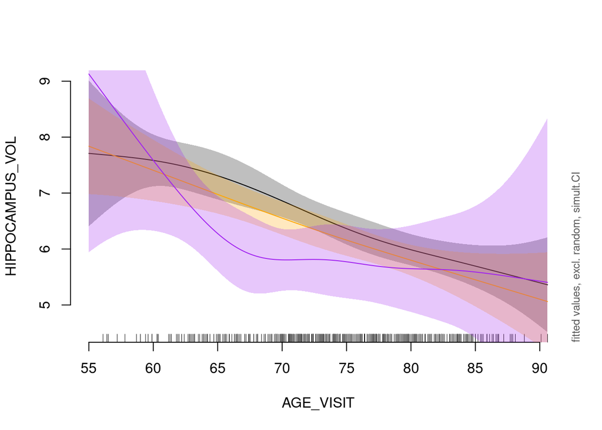

```
## Summary:
##  * DX : numeric predictor; set to the value(s): 1.
##  * PTGENDER : factor; set to the value(s): Male.
##  * APOE4 : numeric predictor; set to the value(s): 2.
##  * PTEDUCAT : numeric predictor; set to the value(s): 16.
##  * AGE_VISIT : numeric predictor; with 200 values ranging from 55.000000 to 90.600000.
##  * NOTE : No random effects in the model to cancel.
##
##  * Simultaneous 95%-CI used :
##      Critical value: 2.886
##      Proportion posterior simulations in pointwise CI: 0.46 (10000 samples)
##      Proportion posterior simulations in simultaneous CI: 0.95 (10000 samples)
##
```

```r
plot_smooth(model1.20, view = "AGE_VISIT", sim.ci = TRUE, cond = list(APOE4 = 2), add = TRUE,col='purple')
```

The intersecting lines and confidence intervals indicate that there is an interaction between `APOE4` and `AGE_VISIT`.

## 1.23

Using the gam with the interaction, what is the derivative of the smooth term for `AGE_VISIT` and `APOE4`=0 at `AGE_VISIT`=60? What is it for `AGE_VISIT`=75 and `APOE4`=0? (Hint: you can use finite differences.)

```r
#choose a row with `APOE4`=0
newd <- mcidata_cx[1,]
newd$AGE_VISIT <- 60 - 1e-05
y1 <- predict(model1.20, newd)

newd$AGE_VISIT <- 60 + 1e-05
y2 <- predict(model1.20, newd)

#calculate difference to estimate effect
(y2-y1)/(2e-05)
```

```
##          13
## -0.03594941
```

```r
#choose a row with `APOE4`=0
newd <- mcidata_cx[1,]
newd$AGE_VISIT <- 75 - 1e-05
y1 <- predict(model1.20, newd)

newd$AGE_VISIT <- 75 + 1e-05
y2 <- predict(model1.20, newd)

#calculate difference to estimate effect
(y2-y1)/(2e-05)
```

```
##          13
## -0.09095349
```

The derivative of the smooth term for AGE_VISIT and APOE4=0 is -0.03594941 at `AGE_VISIT` = 60, and -0.09095349 at `AGE_VISIT` = 75.

## 1.24

What is the derivative of the smooth term for `AGE_VISIT` for `APOE4`=2 at `AGE_VISIT`=60? What is it for `AGE_VISIT`=75 and `APOE4`=2?

```r
#choose a row with `APOE4`=2
newd <- mcidata_cx[21,]
newd$AGE_VISIT <- 60 - 1e-05
y1 <- predict(model1.20, newd)

newd$AGE_VISIT <- 60 + 1e-05
y2 <- predict(model1.20, newd)

#calculate difference to estimate effect
(y2-y1)/(2e-05)
```

```
##        179
## -0.2976912
```

```r
#choose a row with `APOE4`=2
newd <- mcidata_cx[21,]
newd$AGE_VISIT <- 75 - 1e-05
y1 <- predict(model1.20, newd)

newd$AGE_VISIT <- 75 + 1e-05
y2 <- predict(model1.20, newd)

#calculate difference to estimate effect
(y2-y1)/(2e-05)
```

```
##        179
## -0.0305863
```

The derivative of the smooth term for AGE_VISIT and APOE4=2 is -0.2976912 at `AGE_VISIT` = 60, and -0.0305863 at `AGE_VISIT` = 75.

## 1.25

In words, describe how the effect of age is modified by `APOE4`.

For people with age < 65, compared to `APOE4`= 0 or 1, the hippocampal volume decreases more rapidly for people with `APOE4`= 2, such that hippocampal volume is lower in `APOE4`=2 at age = 70 than for `APOE4`=0 or 1. For people with age > 70, compared to `APOE4`= 0 or 1, hippocampal volume decreases less rapidly for people with `APOE4`= 2, with hippocampal volumes being more similar in the three groups at age=85.

## 1.26

Conduct an approximate F test for the interaction between `APOE4` and the smooth for `AGE_VISIT` in the gam. Report the F-statistic, DF numerator and denominator, p-value, and your conclusion.

```r
anova(model1.14, model1.20, test='F')
```

```
## Analysis of Deviance Table
##
## Model 1: HIPPOCAMPUS_VOL ~ s(AGE_VISIT) + s(PTEDUCAT) + DX + PTGENDER +
##     APOE4
## Model 2: HIPPOCAMPUS_VOL ~ s(PTEDUCAT) + s(AGE_VISIT, by = APOE4) + DX +
##     PTGENDER + APOE4
##   Resid. Df Resid. Dev     Df Deviance      F  Pr(>F)
## 1    847.24     767.56
## 2    838.43     751.54 8.8111    16.02 2.0402 0.03368 *
## ---
## Signif. codes:  0 '***' 0.001 '**' 0.01 '*' 0.05 '.' 0.1 ' ' 1
```

## 1.27

Fit a linear model (no smooth terms) with the same terms and report the F-statistic, DF numerator and denominator, pvalue, and your conclusion according to this linear model for the interaction between `APOE4` and `AGE_VISIT`.

```r
model1.27_inter = lm(HIPPOCAMPUS_VOL~DX+PTGENDER+APOE4+
                      PTEDUCAT+AGE_VISIT*APOE4,
                      data=mcidata_cx)
model1.27_no_inter = lm(HIPPOCAMPUS_VOL~DX+PTGENDER+APOE4+
                        PTEDUCAT+AGE_VISIT,
                        data=mcidata_cx)
anova(model1.27_inter, model1.27_no_inter, test='F')
```

```
## Analysis of Variance Table
##
## Model 1: HIPPOCAMPUS_VOL ~ DX + PTGENDER + APOE4 + PTEDUCAT + AGE_VISIT *
##     APOE4
## Model 2: HIPPOCAMPUS_VOL ~ DX + PTGENDER + APOE4 + PTEDUCAT + AGE_VISIT
##   Res.Df    RSS Df Sum of Sq      F Pr(>F)
## 1    849 771.44
## 2    851 772.24 -2  -0.79687 0.4385 0.6452
```

The F-statistic is 0.4385. DF numerator is 2, and denominator is 849. The p-value is 0.6452, greater than our $\alpha$ = 0.05. Therefore, we do not have enough evidence to conclude that the effect of age is significantly modified by `APOE4`.

## 1.28

Which model do you prefer: the gam with interactions or the linear model with interactions? Why?

I prefer the gam with interactions since the edfs are greater than 1 for the interaction terms in gam, indicating that it’s reasonable to use a smooth term.